# Projeto Integrador

#### Modelo Random Forest com hiperparâmtros otimizados

```r
set.seed(123)
(rf <- ranger(flag ~ ., num.trees = 500, mtry = 3, min.node.size = 70, max.depth = 15, data = tr, classification = TRUE, probability = TRUE, num.threads = 8))
```

```
## Ranger result
##
## Call:
##  ranger(flag ~ ., num.trees = 500, mtry = 3, min.node.size = 70,      max.depth = 15, data = tr, classification = TRUE, probability = TRUE,      num.threads = 8)
##
## Type:                             Probability estimation
## Number of trees:                  500
## Sample size:                      15110
## Number of independent variables:  45
## Mtry:                             3
## Target node size:                 70
## Variable importance mode:         none
## Splitrule:                        gini
## OOB prediction error (Brier s.):  0.02723
```

```r
prob_rf <- predict(rf, test)$predictions[,2] #retorna probabilidade

desempenho <- desempenho %>%
  bind_rows(tibble(prob = prob_rf,
                     classes = ifelse(test$flag == "1", "Yes", "No"),
                     metodo = "RF"))

desempenho %>%
  mutate(classes = factor(classes)) %>%
  group_by(metodo) %>%
  roc_auc(classes, prob, event_level = "second") %>%
  arrange(desc(.estimate))
```

```
## # A tibble: 5 × 4
##   metodo      .metric .estimator .estimate
##   <chr>       <chr>   <chr>          <dbl>
## 1 RF          roc_auc binary         0.868
## 2 Elastic-Net roc_auc binary         0.852
## 3 Lasso       roc_auc binary         0.851
## 4 Ridge       roc_auc binary         0.850
## 5 Reg_Log     roc_auc binary         0.840
```

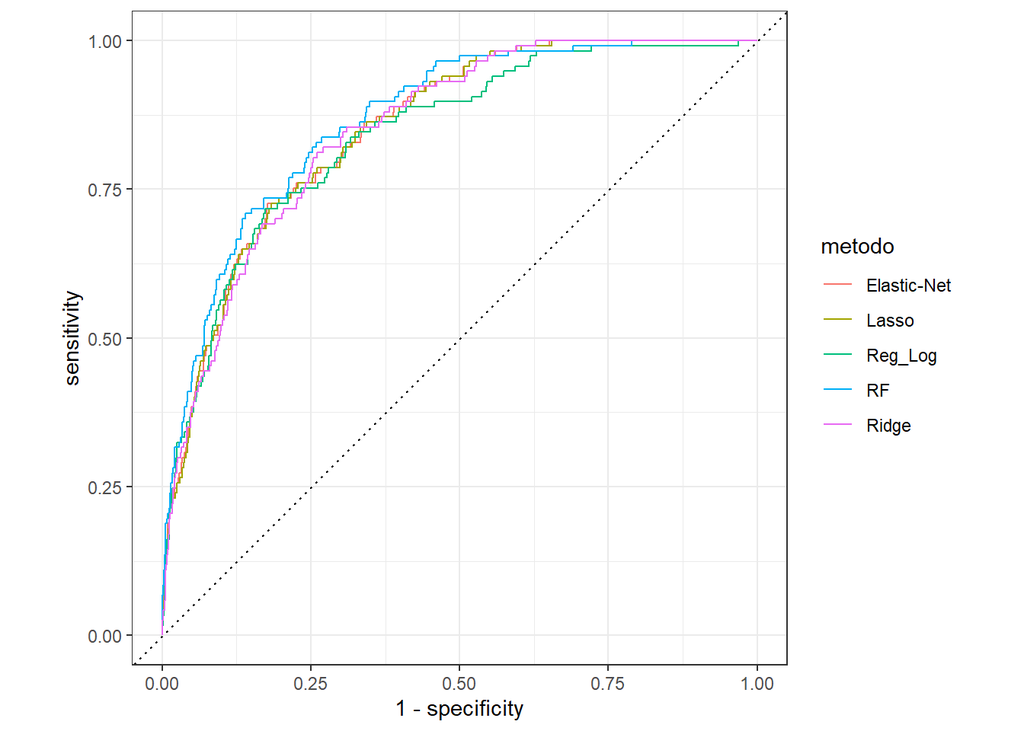

```r
desempenho %>%
  mutate(classes = factor(classes)) %>%
  group_by(metodo) %>%
  roc_curve(classes, prob, event_level = "second") %>%
  autoplot()
```

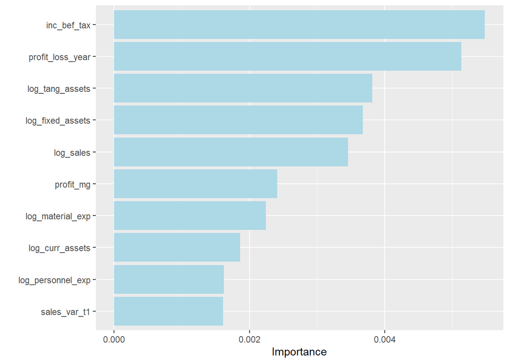

```r
# Importancia das variaveis para o modelo utilizando o método de permutation
set.seed(123)
rf1 <- ranger(flag ~ ., num.trees = 500, mtry = 3, min.node.size = 70, max.depth = 15, data = tr, classification = TRUE, probability = TRUE, num.threads = 8, importance = "permutation")
vip::vip(rf1, aesthetics = list(fill = "lightblue"))
```

### 5.4 XGBoost - Extreme Gradient Boosting Model

Primeiro faremos um gridsearch para otimizar o conjunto de hiperparâmetros do modelo. hiperparâmetros otimizados:

eta: controle da taxa de aprendizado do modelo ou lambda;  
Nrounds: quantidade de árvores colocadas em série;  
Subsample: percentual do total de observações sorteadas disponíveis para treinar cada árvore;  
Colsample_bytree: percentual do total de colunas sorteadas para treinar cada árvore;

```r
start_time <- Sys.time()
set.seed(123)
hiperparametros <- crossing(eta = c(.0075, .01, .025, .05, .075),
                            nrounds = c(500, 750, 1000, 1500),
                            max_depth = c(1, 2, 4),
                            subsample = c(.2, .4, .6, .8), #seleção de parte das observaçoes
                            colsample_bytree = c(.2, .4, 0.6, .8)) #seleção de parte das variáveis


ajusta_bst <- function(splits, eta, nrounds, max_depth, subsample, colsample_bytree) {
  set.seed(123)
  tr <- training(splits)
  test <- testing(splits)

  d_tr <- xgb.DMatrix(label = tr$flag,
                      data = model.matrix(flag ~ ., tr)[,-1])

  fit <- xgb.train(data = d_tr, nrounds = nrounds, max_depth = max_depth, eta = eta, subsample= subsample,
                   colsample_bytree = colsample_bytree, nthread = 24, verbose = FALSE, objective = "binary:logistic")


  #faz obj matriz de teste
  d_test <- xgb.DMatrix(label = test$flag, #tem que ser numero
                      data = model.matrix(flag ~ ., test)[,-1])

  #gera vetor com prob das previsões
  pred_xgb <- predict(fit, d_test)

  auc <- tibble(prob = pred_xgb,
                classes = ifelse(test$flag == "1", "Yes", "No"),
                metodo = "XGBM")  %>%
    mutate(classes = factor(classes)) %>%
    group_by(metodo) %>%
    roc_auc(classes, prob, event_level = "second") %>%
    pull(.estimate) %>%
    as.numeric()

  return(auc)
}

resultados <- rsample::vfold_cv(tr_XGBM, 5) %>%
  crossing(hiperparametros) %>%
  mutate(auc = pmap_dbl(list(splits, eta, nrounds, max_depth, subsample, colsample_bytree), ajusta_bst))

HP_XGBP <- resultados %>%
  group_by(eta, nrounds, max_depth, subsample, colsample_bytree) %>%
  summarise(auc = mean(auc)) %>%
  arrange(desc(auc))

write_csv(HP_XGBP,'HP_XGBP_3.csv')

end_time <- Sys.time()
print(end_time - start_time) #4.1h
```

#### Resultados da otimização de Hiperparâmetros

```r
HP_XGBP <- read.csv("C:/Users/arnch/OneDrive/Documentos/Insper/projeto_integrador/HP_XGBP_3.csv")
HP_XGBP %>%
  arrange(desc(auc)) %>%
  head()
```

```
##      eta nrounds max_depth subsample colsample_bytree    auc
## 1 0.0100     750         4       0.6              0.4 0.9100
## 2 0.0075    1000         4       0.6              0.4 0.9095
## 3 0.0075     750         4       0.6              0.4 0.9092
## 4 0.0075    1000         4       0.4              0.4 0.9089
## 5 0.0100    1000         4       0.6              0.4 0.9088
## 6 0.0100     750         4       0.4              0.8 0.9088
```

Melhor conjunto:  
eta = 0.01  
nrounds = 750  
max_depth = 4  
subsample = 0.6  
colsample_bytree = 0.4

#### Previsão XGBM com hiperparâmetros otimizados

```r
d_tr <- xgb.DMatrix(label =  ifelse(tr$flag == "1", 1, 0),
                    data = model.matrix(flag ~ ., tr)[,-1])

fit_XGBM <- xgboost(data = d_tr, nrounds = 750, max_depth = 4,
                      eta = 0.01, subsample = 0.6, colsample_bytree = 0.4, nthread = 10, verbose = FALSE,
                      objective="binary:logistic")

# erro de teste
# faz o objeto matriz de teste
d_test <- xgb.DMatrix(label = ifelse(test$flag == "1", 1, 0),
                      data = model.matrix(flag ~ ., test)[,-1]) #predição

pred_xgb <- predict(fit_XGBM, d_test)

desempenho <- desempenho %>%
                bind_rows(tibble(prob = pred_xgb,
                                classes = ifelse(test$flag == "1", "Yes", "No"),
                                metodo = "XGBM"))

desempenho %>%
  mutate(classes = factor(classes)) %>%
  group_by(metodo) %>%
  roc_auc(classes, prob, event_level = "second") %>%
  arrange(desc(.estimate))
```

```
## # A tibble: 6 × 4
##   metodo      .metric .estimator .estimate
##   <chr>       <chr>   <chr>          <dbl>
## 1 XGBM        roc_auc binary         0.891
## 2 RF          roc_auc binary         0.868
## 3 Elastic-Net roc_auc binary         0.852
## 4 Lasso       roc_auc binary         0.851
## 5 Ridge       roc_auc binary         0.850
## 6 Reg_Log     roc_auc binary         0.840
```

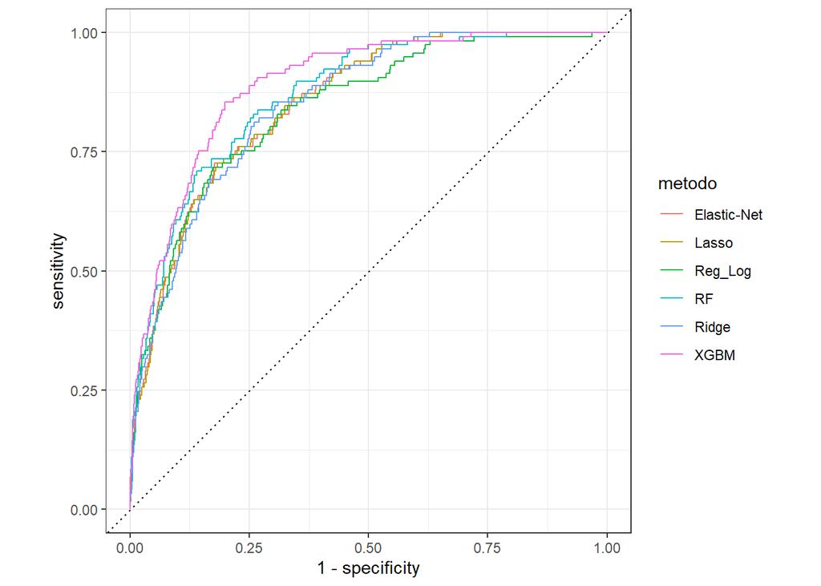

```r
desempenho %>%
  mutate(classes = factor(classes)) %>%
  group_by(metodo) %>%
  roc_curve(classes, prob, event_level = "second") %>%
  autoplot()
```

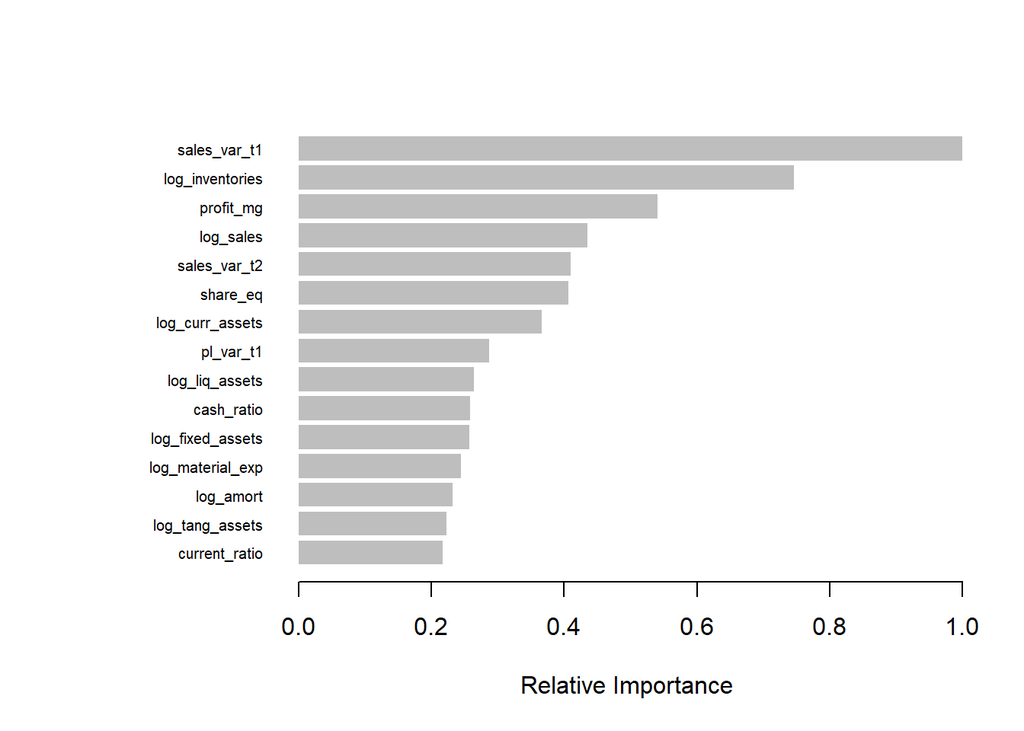

```r
#printa importancia relativa das preditoras - gráfico top15 preditoras
importancia <- xgb.importance(model = fit_XGBM) #legal
importancia_sorted <- importancia %>%
  arrange(desc(Gain)) %>%
  head(15)
xgb.plot.importance(importancia_sorted, rel_to_first = TRUE, xlab = "Relative Importance")
```

# 5. Resultados Finais

## Valores de AUC por modelo e curva ROC

O melhor modelo para realizar as classificações foi o modelo XGBoost, perante a métrica AUC

```
## # A tibble: 6 × 4
##   metodo      .metric .estimator .estimate
##   <chr>       <chr>   <chr>          <dbl>
## 1 XGBM        roc_auc binary         0.891
## 2 RF          roc_auc binary         0.868
## 3 Elastic-Net roc_auc binary         0.852
## 4 Lasso       roc_auc binary         0.851
## 5 Ridge       roc_auc binary         0.850
## 6 Reg_Log     roc_auc binary         0.840
```

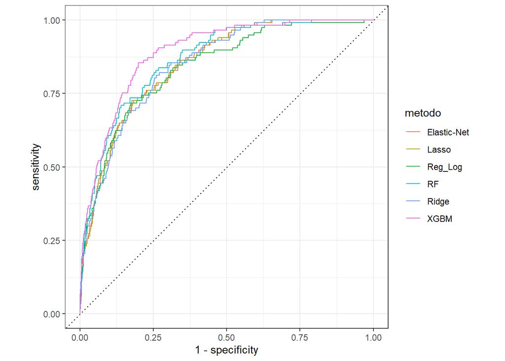

## Outras métricas de performance

Após a escolha final do modelo XGBoost, rodamos também uma matriz de confusão para diferentes thresholds, de forma a avaliar diferentes métricas como acuracidade total, Sensibilidade, Especificidade, Valores Preditos Positivos (PPV) e Valores Preditos Negativos (NPV) de forma a possibilitar a definição final do threshold do modelo que melhor atenderia os possíveis objetivos de negócio ao se implementar este modelo.

```r
coords(roc(y_test, pred_xgb), c(.05,.1,.2,.3,.4,.5,.6,.7,.8,.9),
       ret = c("threshold","accuracy", "sensitivity", "1-specificity", "ppv", "npv"))
```

```
##    threshold accuracy sensitivity 1-specificity    ppv    npv
## 1       0.05   0.8729     0.66667     0.1204589 0.1503 0.9880
## 2       0.10   0.9304     0.47863     0.0551762 0.2171 0.9827
## 3       0.20   0.9606     0.29915     0.0183010 0.3431 0.9777
## 4       0.30   0.9677     0.22222     0.0084676 0.4561 0.9755
## 5       0.40   0.9685     0.16239     0.0057361 0.4750 0.9738
## 6       0.50   0.9688     0.12821     0.0043704 0.4839 0.9728
## 7       0.60   0.9690     0.07692     0.0024583 0.5000 0.9713
## 8       0.70   0.9701     0.05983     0.0008194 0.7000 0.9708
## 9       0.80   0.9696     0.01709     0.0000000 1.0000 0.9695
## 10      0.90   0.9690     0.00000     0.0000000    NaN 0.9690
```

## Comparativo da importancia das variáveis de modelos selecionados

agora colocaremos abaixo a importancia relativa de alguns modelos, para compararmos mais facilmente as diferenças de escolha das variáveis.

XGBoost

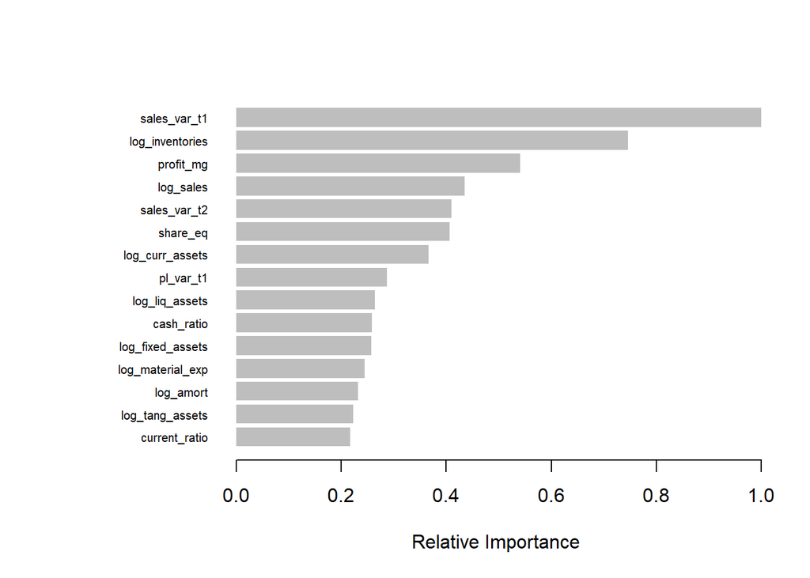

Random Forest

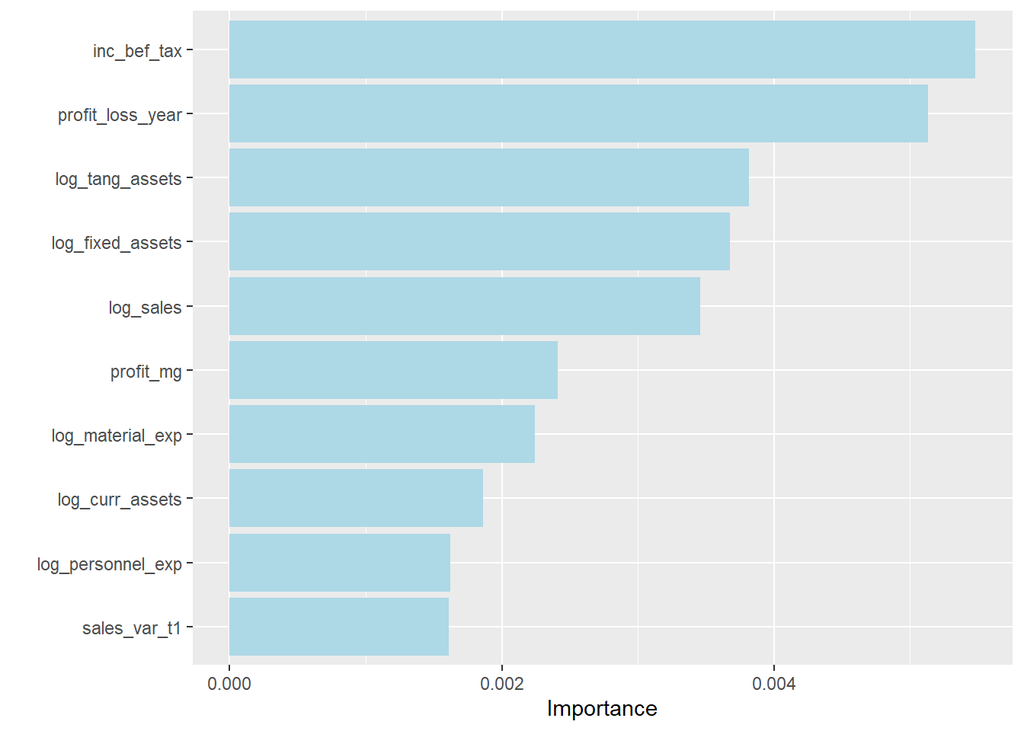